# Final Project - PSTAT 131

Ellie Huang

12-08-2024

# Introduction

In the realm of online multiplayer games, League of Legends stands out as one of the most popular and competitive titles, engaging millions of players worldwide in fast-paced, team-based battles. Each match in League of Legends pits two teams of five players against each other, with the primary objective being to destroy the enemy’s Nexus, a critical structure located at the heart of their base. Players control champions, unique characters with specific abilities, roles, and attributes that contribute to the team’s strategy and performance. Throughout the game, players accumulate experience points (XP), gold, and items, all of which enhance their champion’s abilities and influence their impact on the match.

A central performance metric in League of Legends is the Kill/Death/Assist (KDA) ratio, which quantifies a player’s effectiveness by balancing their offensive contributions (kills and assists) against their defensive responsibility (avoiding deaths). High KDA ratios are generally associated with skilled gameplay and strategic awareness, making KDA a valuable indicator for analyzing performance. This project is focused on the statistics taken from players ranked Master and above, in the North America (NA) region. The primary goal of this project is to build a model that can predict a player’s KDA based on various in-game factors, such as gold earned, role, and match duration. By examining these variables, my aim is to uncover patterns that influence KDA and contribute to a deeper understanding of gameplay dynamics.

# Source of Data

The data for this project was sourced from the Riot Games Developer API (Riot Games, Inc., 2024), which provides comprehensive in-game statistics for League of Legends. 1497 observations of key metrics such as match history, champion stats, and player rankings were collected to support KDA prediction analysis. Data access required an API key, with relevant match data filtered for this project’s focus.

For API details, visit the Riot Games Developer Portal: https://developer.riotgames.com/.

Citation: Riot Games, Inc. (2024). Riot Games Developer Portal. https://developer.riotgames.com/.

A codebook of variables and their descriptions are attached as a separate .doc file.

# Exploratory Data Analysis (EDA)

## Missing data

There seems to be a lot of missing data for neutral_minions_killed, since this statistic is specific to a certain player role, this variable should be removed. There is also missing data for vision score, so I will remove the observations that are NA. For wards_placed and wards_killed, they will be removed later in the process (they are highly correlated with vision_score and thus should be removed). There also looks to be a lot of missing data for total_heals_on_teammates and total_damage_shielded_on_teammates, so I will remove those variables as well. This also makes sense because heals and damage shielded on teammates doesn’t seem to be exactly relevant to the a player’s KDA/individual performance.

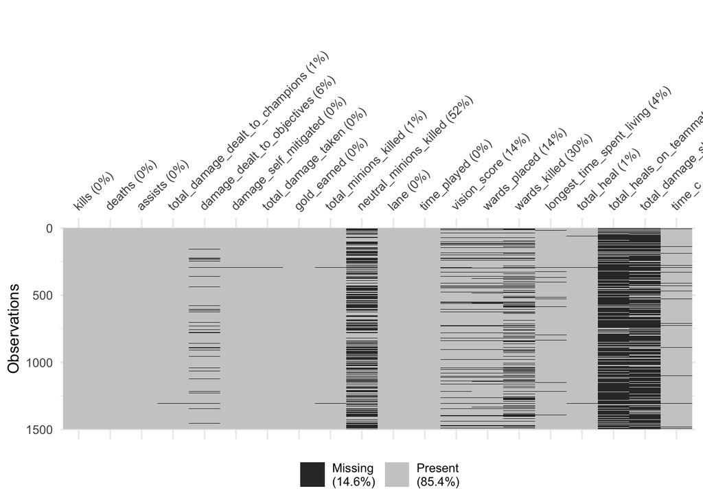

```r
player_stats <- read.csv("player_stats.csv")
player_stats <- player_stats %>%
  select(-X)
naniar::vis_miss(player_stats)
```

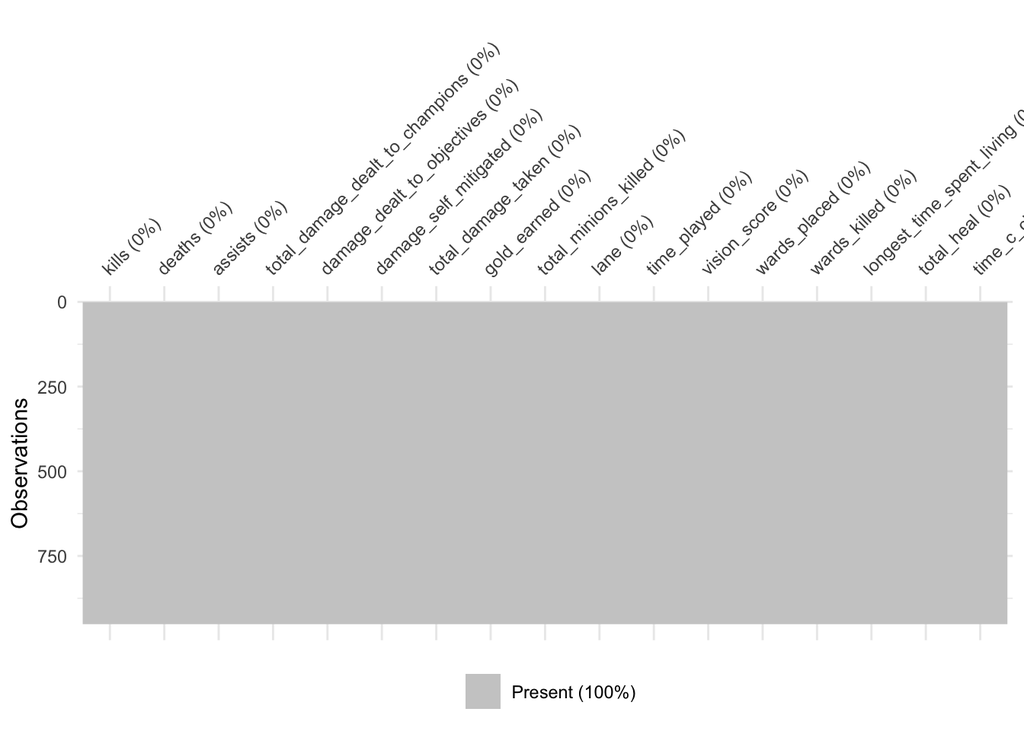

```r
player_stats <- player_stats %>%
  select(-neutral_minions_killed, -total_heals_on_teammates, -total_damage_shielded_on_teammates) %>%
  drop_na() # remove rows with NA obs

naniar::vis_miss(player_stats)
```

## Visualize distribution for KDA

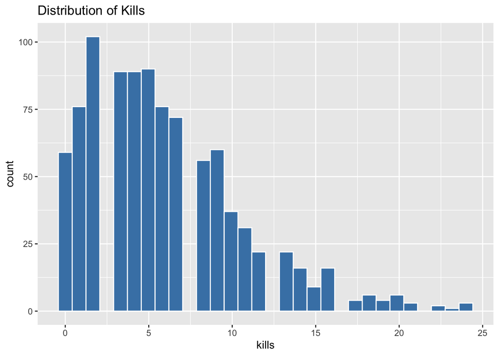

```r
# Histogram for KDA components
ggplot(player_stats, aes(x = kills)) +
  geom_histogram(color = "white", fill = "steelblue") +
  ggtitle("Distribution of Kills")
```

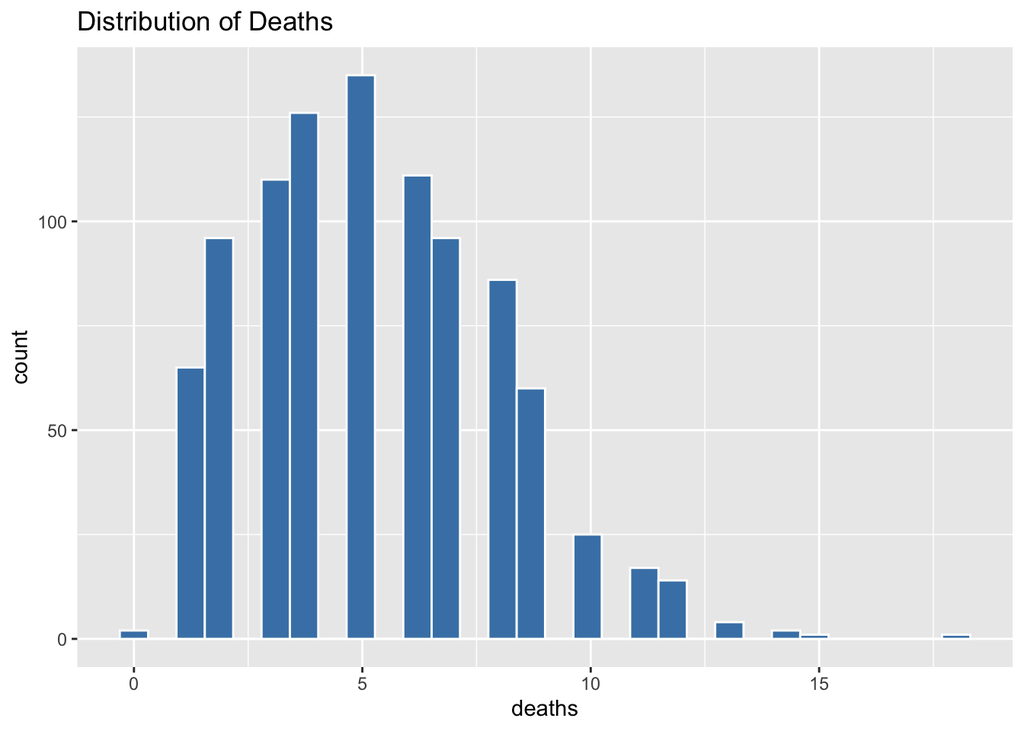

```r
ggplot(player_stats, aes(x = deaths)) +
  geom_histogram(color = "white", fill = "steelblue") +
  ggtitle("Distribution of Deaths")
```

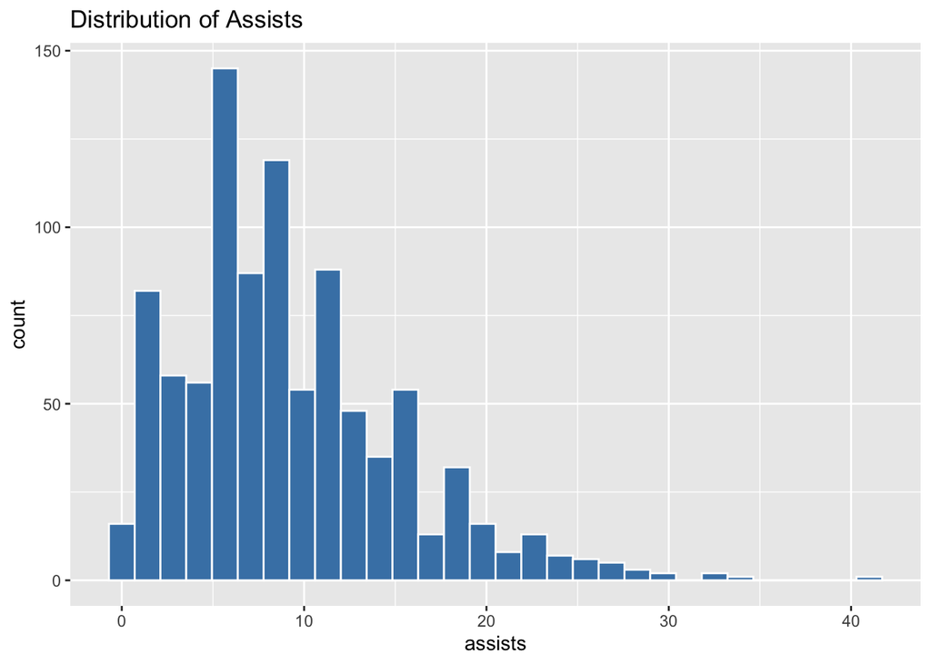

```r
ggplot(player_stats, aes(x = assists)) +
  geom_histogram(color = "white", fill = "steelblue") +
  ggtitle("Distribution of Assists")
```

```r
# Now, calculate the KDA variable = (kills + assists)/deaths to the dataset and remove kills, deaths, and assists because they would be redundant, since each is directly used to calculate the KDA.

player_stats <- player_stats %>%
  mutate(kda = if_else(deaths > 0, (kills + assists) / deaths, kills + assists))

summary(player_stats$kda)
```

```
##    Min. 1st Qu.  Median    Mean 3rd Qu.    Max.
##   0.000   1.667   2.875   4.209   5.000  33.000
```

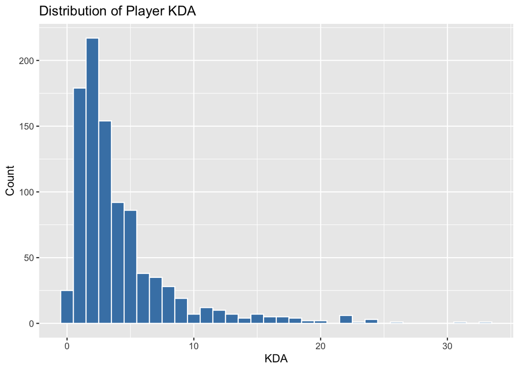

```r
ggplot(player_stats, aes(x = kda)) +
  geom_histogram(binwidth = 1, fill = "steelblue", color = "white") +
  labs(title = "Distribution of Player KDA", x = "KDA", y = "Count")
```

KDA looks to be heavily right skewed, with the median being 2.875, and the most players having a KDA between 1 and 5. Similarly, the separate stats of kills, deaths, and assists were also right skewed.

### KDA relationships

```r
fig_1 <- player_stats %>%
  select(where(is.numeric)) %>%
  pivot_longer(cols = -c(kda, kills, deaths, assists), names_to = "Variable", values_to = "Value") %>%
  ggplot(aes(x = Value, y = kda)) +
  geom_point(alpha = 0.6) +
  geom_smooth(method = "lm", se = FALSE, color = "red") +
  facet_wrap(~ Variable, scales = "free_x", ncol = 3) +
  labs(title = "Relationships with KDA", x = "Value", y = "KDA")

ggsave("relationships_with_kda.png", fig_1, width = 20, height = 15)
```

## Categorical Variables

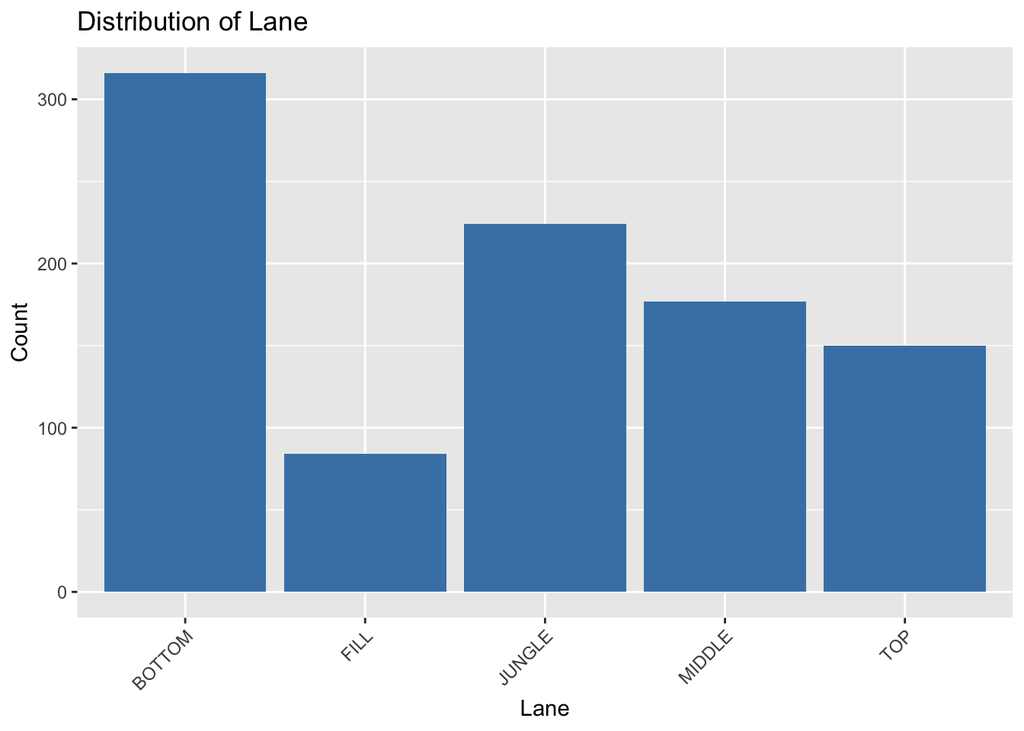

```r
player_stats <- player_stats %>%
  mutate(lane = as.factor(lane))

player_stats %>%
  ggplot(aes(x = lane)) +
  geom_bar(fill = "steelblue") +
  labs(title = "Distribution of Lane", x = "Lane", y = "Count") +
  theme(axis.text.x = element_text(angle = 45, hjust = 1))
```

We convert the character variable to factor. Looking at the distribution of the categorical variable, the most selected role was Bottom, with over 300 players, and the least selected role was Fill, with less than 100 players.

## Correlation

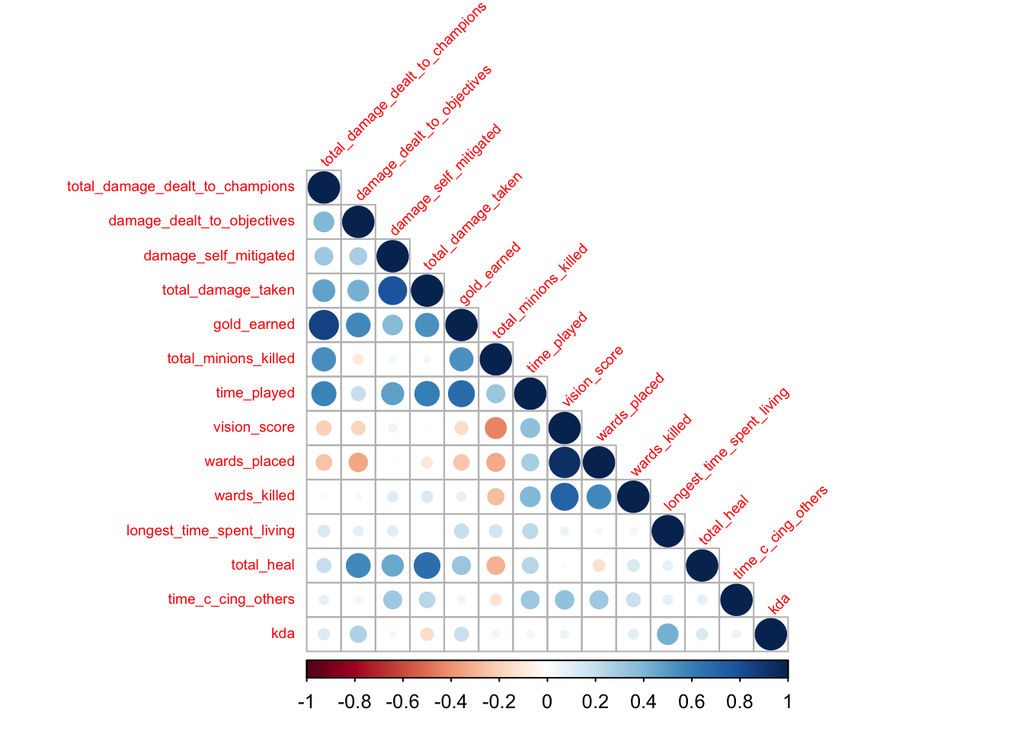

```r
numeric_columns <- player_stats %>%
  select(where(is.numeric)) %>%
  select(-c(kills, assists, deaths))

cor_matrix <- cor(numeric_columns)
corrplot(cor_matrix, "circle", type = "lower", tl.cex = 0.6, tl.srt = 45)
```

```r
# Identify pairs of columns with correlation > 0.9
high_corr_pairs <- which(abs(cor_matrix) > 0.9, arr.ind = TRUE)

# Exclude self-correlations
high_corr_pairs <- high_corr_pairs[high_corr_pairs[, 1] != high_corr_pairs[, 2], ]

# Review and decide which columns to drop
print(high_corr_pairs)
```

```
##              row col
## wards_placed   9   8
## vision_score   8   9
```

```r
player_stats <- player_stats %>%
  select(-wards_placed, -wards_killed, -total_damage_dealt_to_champions)
```

## Outliers

```r
fig_2 <- player_stats %>%
  pivot_longer(cols = where(is.numeric), names_to = "Variable", values_to = "Value") %>%
  ggplot(aes(x = Variable, y = Value)) +
  geom_boxplot(fill = "blue", alpha = 0.6) +
  facet_wrap(~ Variable, scales = "free", ncol = 2) +
  labs(title = "Outlier Detection by Variable", x = "Variable", y = "Value") +
  coord_flip() +
  theme(axis.text.x = element_blank(),
    axis.ticks.x = element_blank(),
    strip.text = element_text(size = 10),
    plot.title = element_text(hjust = 0.5))

ggsave("outliers.png", fig_2, width = 20, height = 15)
```

```r
cap_outliers <- function(variable) {
  Q1 <- quantile(variable, 0.25, na.rm = TRUE)
  Q3 <- quantile(variable, 0.75, na.rm = TRUE)
  IQR <- Q3 - Q1
  lower_bound <- Q1 - 1.5 * IQR
  upper_bound <- Q3 + 1.5 * IQR
  variable <- ifelse(variable < lower_bound, lower_bound,
                     ifelse(variable > upper_bound, upper_bound, variable))
  return(variable)
}

predictors <- c("damage_dealt_to_objectives", "longest_time_spent_living",
                "gold_earned", "total_damage_taken",
                "total_heal", "vision_score")

# Apply IQR method to cap outliers
player_stats <- player_stats %>%
  mutate(across(all_of(predictors), cap_outliers))
```

Since I intend to evaluate my models on metrics like RMSE and MSE, which are sensitive to large errors and are often caused by outliers, capping can lead to fairer evaluations of model performance.

# Testing/Training Split

```r
player_split <- initial_split(player_stats, prop = 0.8, strata = kda)

player_train <- training(player_split)
player_test <- testing(player_split)
```

# Recipe

```r
player_recipe <- recipe(kda ~ damage_dealt_to_objectives +
                                  damage_self_mitigated +
                                  total_damage_taken +
                                  gold_earned +
                                  total_minions_killed +
                                  lane +
                                  time_played +
                                  vision_score +
                                  longest_time_spent_living +
                                  total_heal +
                                  time_c_cing_others,
                        data = player_train) %>%
  step_dummy(all_nominal_predictors()) %>%
  step_normalize(all_numeric_predictors())
```

# K-fold Cross Validation

```r
folds <- vfold_cv(player_train, v = 5, strata = kda)
```

# Define Models - Elastic Net, Random Forest, Gradient Boosted Trees, Support Vector Machines

```r
elastic_net_model <- linear_reg(
  penalty = tune(),  # Regularization strength
  mixture = tune()   # Balance between Ridge (0) and Lasso (1)
) %>%
  set_engine("glmnet")

rf_model <- rand_forest(
  mtry = tune(),         # Number of variables to try at each split
  trees = tune(),          # Number of trees
  min_n = tune()         # Minimum data points in a node
) %>%
  set_engine("ranger") %>%
  set_mode("regression")

gbt_model <- boost_tree(
  trees = tune(),         # Number of trees
  learn_rate = tune(),  # Learning rate
  tree_depth = tune()   # Maximum tree depth
) %>%
  set_engine("xgboost") %>%
  set_mode("regression")

svm_model <- svm_rbf(
  cost = tune(),      # Regularization parameter
  rbf_sigma = tune()  # Kernel parameter
) %>%
  set_engine("kernlab") %>%
  set_mode("regression")

metric = metric_set(rmse)
```

# Applying Models to Player Data

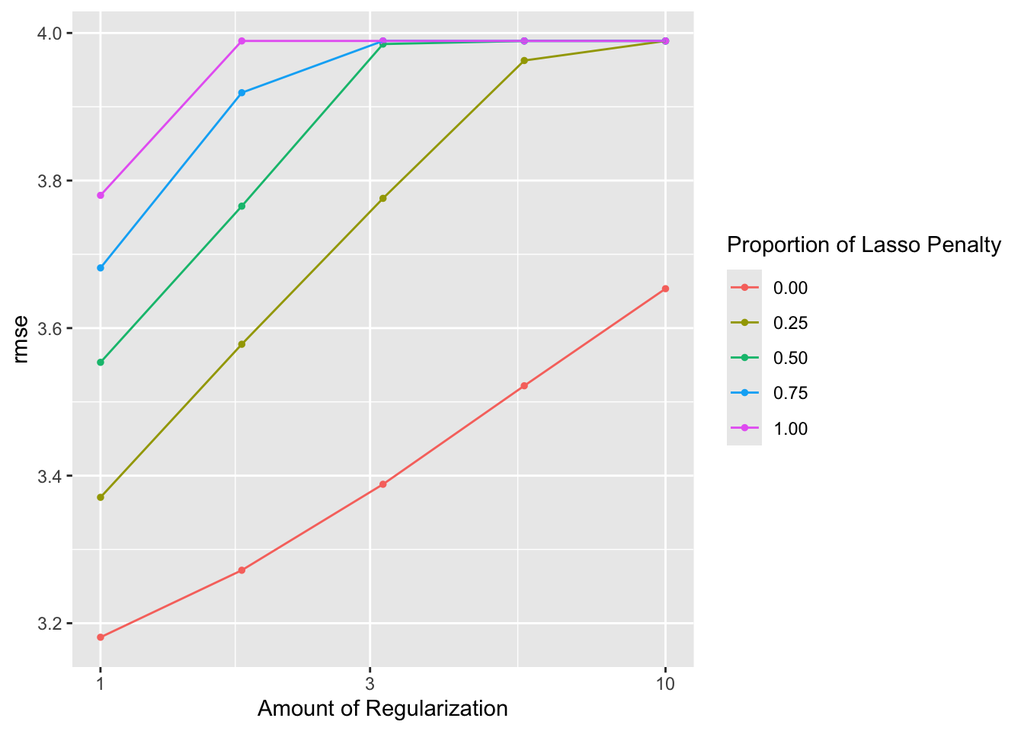

```r
# Workflow
elastic_net_workflow <- workflow() %>%
  add_recipe(player_recipe) %>%
  add_model(elastic_net_model)

# Define Grid for Hyperparameter Tuning
elastic_net_grid <- grid_regular(
  penalty(range = c(0.0001, 1)),
  mixture(range = c(0, 1)),
  levels = 5
)

elastic_net_results <- tune_grid(
  elastic_net_workflow,
  resamples = folds,
  grid = elastic_net_grid,
  metrics = metric # Metrics for evaluation
)

autoplot(elastic_net_results)
```

```r
elastic_net_metrics <- elastic_net_results %>%
  collect_metrics() %>%
  filter(.metric == "rmse") %>%
  mutate(mse = mean^2)

print(elastic_net_metrics)
```

```
## # A tibble: 25 × 9
##    penalty mixture .metric .estimator  mean     n std_err .config            mse
##      <dbl>   <dbl> <chr>   <chr>      <dbl> <int>   <dbl> <chr>            <dbl>
##  1    1.00    0    rmse    standard    3.18     5   0.221 Preprocessor1_M…  10.1
##  2    1.78    0    rmse    standard    3.27     5   0.229 Preprocessor1_M…  10.7
##  3    3.16    0    rmse    standard    3.39     5   0.237 Preprocessor1_M…  11.5
##  4    5.62    0    rmse    standard    3.52     5   0.244 Preprocessor1_M…  12.4
##  5   10       0    rmse    standard    3.65     5   0.248 Preprocessor1_M…  13.3
##  6    1.00    0.25 rmse    standard    3.37     5   0.229 Preprocessor1_M…  11.4
##  7    1.78    0.25 rmse    standard    3.58     5   0.243 Preprocessor1_M…  12.8
##  8    3.16    0.25 rmse    standard    3.78     5   0.248 Preprocessor1_M…  14.3
##  9    5.62    0.25 rmse    standard    3.96     5   0.253 Preprocessor1_M…  15.7
## 10   10       0.25 rmse    standard    3.99     5   0.250 Preprocessor1_M…  15.9
## # ℹ 15 more rows
```

```r
best_elastic_net <- elastic_net_metrics %>%
  arrange(mse) %>%
  head(1)

# View the best model's MSE
best_elastic_net
```

```
## # A tibble: 1 × 9
##   penalty mixture .metric .estimator  mean     n std_err .config             mse
##     <dbl>   <dbl> <chr>   <chr>      <dbl> <int>   <dbl> <chr>             <dbl>
## 1    1.00       0 rmse    standard    3.18     5   0.221 Preprocessor1_Mo…  10.1
```

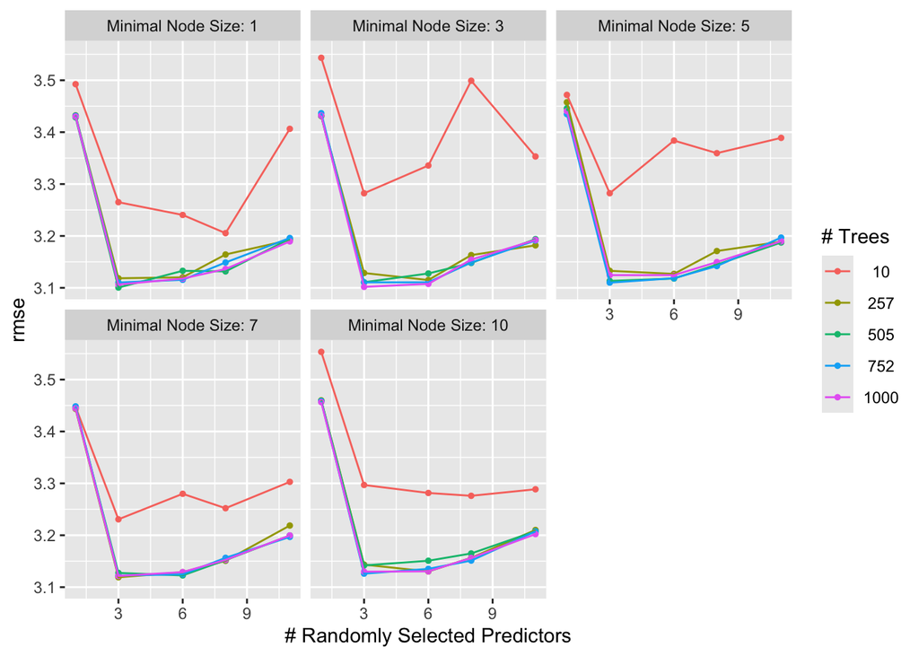

```r
rf_workflow <- workflow() %>%
  add_recipe(player_recipe) %>%
  add_model(rf_model)

# Hyperparameter tuning
rf_grid <- grid_regular(
  mtry(range = c(1, 11)),
  trees(range = c(10, 1000)),
  min_n(range = c(1, 10)),
  levels = 5
)

rf_results <- tune_grid(
  rf_workflow,
  resamples = folds,
  grid = rf_grid,
  metrics = metric
)

autoplot(rf_results)
```

```r
rf_metrics <- rf_results %>%
  collect_metrics() %>%
  filter(.metric == "rmse") %>%
  mutate(mse = mean^2)

print(rf_metrics)
```

```
## # A tibble: 125 × 10
##     mtry trees min_n .metric .estimator  mean     n std_err .config          mse
##    <int> <int> <int> <chr>   <chr>      <dbl> <int>   <dbl> <chr>          <dbl>
##  1     1    10     1 rmse    standard    3.49     5   0.241 Preprocessor1… 12.2
##  2     3    10     1 rmse    standard    3.27     5   0.140 Preprocessor1… 10.7
##  3     6    10     1 rmse    standard    3.24     5   0.165 Preprocessor1… 10.5
##  4     8    10     1 rmse    standard    3.21     5   0.192 Preprocessor1… 10.3
##  5    11    10     1 rmse    standard    3.41     5   0.203 Preprocessor1… 11.6
##  6     1   257     1 rmse    standard    3.43     5   0.228 Preprocessor1… 11.8
##  7     3   257     1 rmse    standard    3.12     5   0.200 Preprocessor1…  9.72
##  8     6   257     1 rmse    standard    3.12     5   0.192 Preprocessor1…  9.74
##  9     8   257     1 rmse    standard    3.16     5   0.188 Preprocessor1… 10.0
## 10    11   257     1 rmse    standard    3.19     5   0.206 Preprocessor1… 10.2
## # ℹ 115 more rows
```

```r
best_rf <- rf_metrics %>%
  arrange(mse) %>%
  head(1)

best_rf
```

```
## # A tibble: 1 × 10
##    mtry trees min_n .metric .estimator  mean     n std_err .config           mse
##   <int> <int> <int> <chr>   <chr>      <dbl> <int>   <dbl> <chr>           <dbl>
## 1     3   505     1 rmse    standard    3.10     5   0.189 Preprocessor1_…  9.61
```

From the autoplot, it seems like the model generally performed better with higher number of trees and the number of randomly selected predictors of being around 3. The MSE for the best random forest model was around 9.613246 with mtry = 3, trees = 505, and min_n = 1.

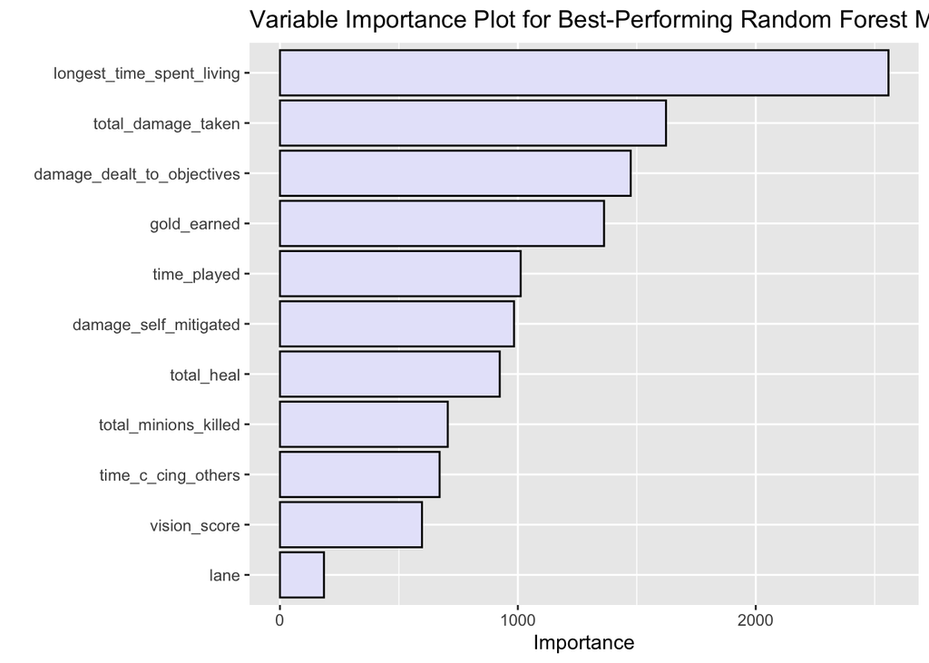

```r
library(vip)

best_vars <- best_rf %>%
  select(mtry, trees, min_n)

best_rf_vars <- rand_forest(
  mtry = best_vars$mtry,
  trees = best_vars$trees,
  min_n = best_vars$min_n
) %>%
  set_engine("ranger", importance = "impurity") %>%
  set_mode("regression")

best_rf_fit <- best_rf_vars %>%
  fit(kda ~ damage_dealt_to_objectives +
                                  damage_self_mitigated +
                                  total_damage_taken +
                                  gold_earned +
                                  total_minions_killed +
                                  lane +
                                  time_played +
                                  vision_score +
                                  longest_time_spent_living +
                                  total_heal +
                                  time_c_cing_others, data = player_train)

vip(best_rf_fit$fit, num_features = 12, geom = "col", aesthetics = list(color = "black", fill = "lavender")) +
  labs(title = "Variable Importance Plot for Best-Performing Random Forest Model")
```

The variables longest_time_spent_living, total_damage_taken, and damage_dealt_to_objectives were found to be the most significant predictors of KDA, likely reflecting a player’s skill and contribution to team objectives. On the other hand, lane and vision_score contributed little to the model’s predictive accuracy, suggesting their limited relevance to performance in terms of KDA. This might diminish the importance of the initial lane assignment for predicting overall performance. This is consistent with the results of the correlation matrix of predictors, which can be found in the EDA section.

```r
updated_recipe <- recipe(kda ~ damage_dealt_to_objectives +
                                  damage_self_mitigated +
                                  total_damage_taken +
                                  gold_earned +
                                  total_minions_killed +
                                  time_played +
                                  vision_score +
                                  longest_time_spent_living +
                                  total_heal +
                                  time_c_cing_others,
                        data = player_train) %>%
  step_normalize(all_numeric_predictors())
```

```r
elnet_workflow_new <- workflow() %>%
  add_recipe(updated_recipe) %>%
  add_model(elastic_net_model)

# Hyperparameter tuning
elnet_grid_new <- grid_regular(
  penalty(range = c(0.0001, 1)),
  mixture(range = c(0, 1)),
  levels = 5
)

elnet_results_new <- tune_grid(
  elnet_workflow_new,
  resamples = folds,
  grid = elnet_grid_new,
  metrics = metric
)

elnet_metrics_new <- elnet_results_new %>%
  collect_metrics() %>%
  filter(.metric == "rmse") %>%
  mutate(mse = mean^2)

print(elnet_metrics_new)
```

```
## # A tibble: 25 × 9
##    penalty mixture .metric .estimator  mean     n std_err .config            mse
##      <dbl>   <dbl> <chr>   <chr>      <dbl> <int>   <dbl> <chr>            <dbl>
##  1    1.00    0    rmse    standard    3.18     5   0.222 Preprocessor1_M…  10.1
##  2    1.78    0    rmse    standard    3.27     5   0.229 Preprocessor1_M…  10.7
##  3    3.16    0    rmse    standard    3.39     5   0.237 Preprocessor1_M…  11.5
##  4    5.62    0    rmse    standard    3.52     5   0.244 Preprocessor1_M…  12.4
##  5   10       0    rmse    standard    3.65     5   0.247 Preprocessor1_M…  13.3
##  6    1.00    0.25 rmse    standard    3.37     5   0.230 Preprocessor1_M…  11.4
##  7    1.78    0.25 rmse    standard    3.58     5   0.243 Preprocessor1_M…  12.8
##  8    3.16    0.25 rmse    standard    3.78     5   0.248 Preprocessor1_M…  14.3
##  9    5.62    0.25 rmse    standard    3.96     5   0.253 Preprocessor1_M…  15.7
## 10   10       0.25 rmse    standard    3.99     5   0.250 Preprocessor1_M…  15.9
## # ℹ 15 more rows
```

```r
best_elnet_new <- elnet_metrics_new %>%
  arrange(mse) %>%
  head(1)

best_elnet_new
```

```
## # A tibble: 1 × 9
##   penalty mixture .metric .estimator  mean     n std_err .config             mse
##     <dbl>   <dbl> <chr>   <chr>      <dbl> <int>   <dbl> <chr>             <dbl>
## 1    1.00       0 rmse    standard    3.18     5   0.222 Preprocessor1_Mo…  10.1
```

The elastic net model performed worse with an MSE of 10.11033 with the updated player recipe with lane dropped.

```r
rf_grid_new <- grid_regular(
  mtry(range = c(1, 11)),
  trees(range = c(50, 500)),
  min_n(range = c(1, 10)),
  levels = 5
)

rf_workflow_new <- workflow() %>%
  add_recipe(updated_recipe) %>%
  add_model(rf_model)

# Perform hyperparameter tuning
rf_results_new <- tune_grid(
  rf_workflow_new,
  resamples = folds,
  grid = rf_grid_new,
  metrics = metric
)

rf_metrics_new <- rf_results_new %>%
  collect_metrics() %>%
  filter(.metric == "rmse") %>%
  mutate(mse = mean^2)

# Find the best model
best_rf_new <- rf_metrics_new %>%
  arrange(mse) %>%
  head(1)

# View the best model's metrics
print(best_rf_new)
```

```
## # A tibble: 1 × 10
##    mtry trees min_n .metric .estimator  mean     n std_err .config           mse
##   <int> <int> <int> <chr>   <chr>      <dbl> <int>   <dbl> <chr>           <dbl>
## 1     3   387     1 rmse    standard    3.08     5   0.191 Preprocessor1_…  9.50
```

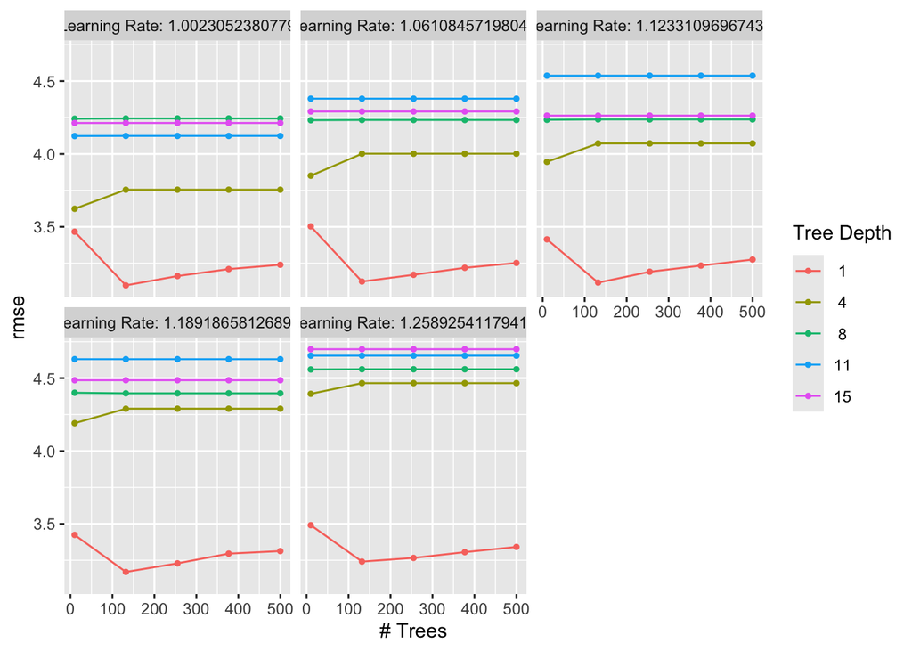

```r
# Workflow for Gradient Boosted Trees
gbt_workflow <- workflow() %>%
  add_recipe(player_recipe) %>%
  add_model(gbt_model)

# Hyperparameter tuning
gbt_grid <- grid_regular(
  learn_rate(range = c(0.001, 0.1)),
  trees(range = c(10, 500)),
  tree_depth(range = c(1, 15)),
  levels = 5
)

gbt_results <- tune_grid(
  gbt_workflow,
  resamples = folds,
  grid = gbt_grid,
  metrics = metric
)

autoplot(gbt_results)
```

```r
gbt_metrics <- gbt_results %>%
  collect_metrics() %>%
  filter(.metric == "rmse") %>%
  mutate(mse = mean^2)

print(gbt_metrics)
```

```
## # A tibble: 125 × 10
##    trees tree_depth learn_rate .metric .estimator  mean     n std_err .config
##    <int>      <int>      <dbl> <chr>   <chr>      <dbl> <int>   <dbl> <chr>
##  1    10          1       1.00 rmse    standard    3.47     5   0.228 Preproces…
##  2   132          1       1.00 rmse    standard    3.10     5   0.177 Preproces…
##  3   255          1       1.00 rmse    standard    3.16     5   0.173 Preproces…
##  4   377          1       1.00 rmse    standard    3.21     5   0.171 Preproces…
##  5   500          1       1.00 rmse    standard    3.24     5   0.175 Preproces…
##  6    10          4       1.00 rmse    standard    3.62     5   0.138 Preproces…
##  7   132          4       1.00 rmse    standard    3.75     5   0.125 Preproces…
##  8   255          4       1.00 rmse    standard    3.75     5   0.125 Preproces…
##  9   377          4       1.00 rmse    standard    3.75     5   0.125 Preproces…
## 10   500          4       1.00 rmse    standard    3.75     5   0.125 Preproces…
## # ℹ 115 more rows
## # ℹ 1 more variable: mse <dbl>
```

```r
best_gbt <- gbt_metrics %>%
  arrange(mse) %>%
  head(1)

best_gbt
```

```
## # A tibble: 1 × 10
##   trees tree_depth learn_rate .metric .estimator  mean     n std_err .config
##   <int>      <int>      <dbl> <chr>   <chr>      <dbl> <int>   <dbl> <chr>
## 1   132          1       1.00 rmse    standard    3.10     5   0.177 Preprocess…
## # ℹ 1 more variable: mse <dbl>
```

From the autoplot, it looks like the model generally performed better with a lower tree depth and number of trees around 100. The MSE for the best gradient boosted trees model was around 9.599176, with trees = 132, tree_depth = 1, and learn_rate = 1.002305.

```r
gbt_workflow_new <- workflow() %>%
  add_recipe(updated_recipe) %>%
  add_model(gbt_model)

# Hyperparameter tuning
gbt_grid_new <- grid_regular(
  learn_rate(range = c(0.001, 0.1)),
  trees(range = c(10, 500)),
  tree_depth(range = c(1, 15)),
  levels = 5
)

gbt_results_new <- tune_grid(
  gbt_workflow_new,
  resamples = folds,
  grid = gbt_grid_new,
  metrics = metric
)

gbt_metrics_new <- gbt_results_new %>%
  collect_metrics() %>%
  filter(.metric == "rmse") %>%
  mutate(mse = mean^2)

print(gbt_metrics_new)
```

```
## # A tibble: 125 × 10
##    trees tree_depth learn_rate .metric .estimator  mean     n std_err .config
##    <int>      <int>      <dbl> <chr>   <chr>      <dbl> <int>   <dbl> <chr>
##  1    10          1       1.00 rmse    standard    3.47     5   0.228 Preproces…
##  2   132          1       1.00 rmse    standard    3.13     5   0.175 Preproces…
##  3   255          1       1.00 rmse    standard    3.18     5   0.181 Preproces…
##  4   377          1       1.00 rmse    standard    3.21     5   0.171 Preproces…
##  5   500          1       1.00 rmse    standard    3.24     5   0.176 Preproces…
##  6    10          4       1.00 rmse    standard    3.83     5   0.219 Preproces…
##  7   132          4       1.00 rmse    standard    3.97     5   0.214 Preproces…
##  8   255          4       1.00 rmse    standard    3.97     5   0.214 Preproces…
##  9   377          4       1.00 rmse    standard    3.97     5   0.214 Preproces…
## 10   500          4       1.00 rmse    standard    3.97     5   0.214 Preproces…
## # ℹ 115 more rows
## # ℹ 1 more variable: mse <dbl>
```

```r
best_gbt_new <- gbt_metrics_new %>%
  arrange(mse) %>%
  head(1)

best_gbt_new
```

```
## # A tibble: 1 × 10
##   trees tree_depth learn_rate .metric .estimator  mean     n std_err .config
##   <int>      <int>      <dbl> <chr>   <chr>      <dbl> <int>   <dbl> <chr>
## 1   132          1       1.06 rmse    standard    3.12     5   0.171 Preprocess…
## # ℹ 1 more variable: mse <dbl>
```

The error of the updated gradient boosted trees model was higher, indicating that it did not perform better with the dropped lane predictor.

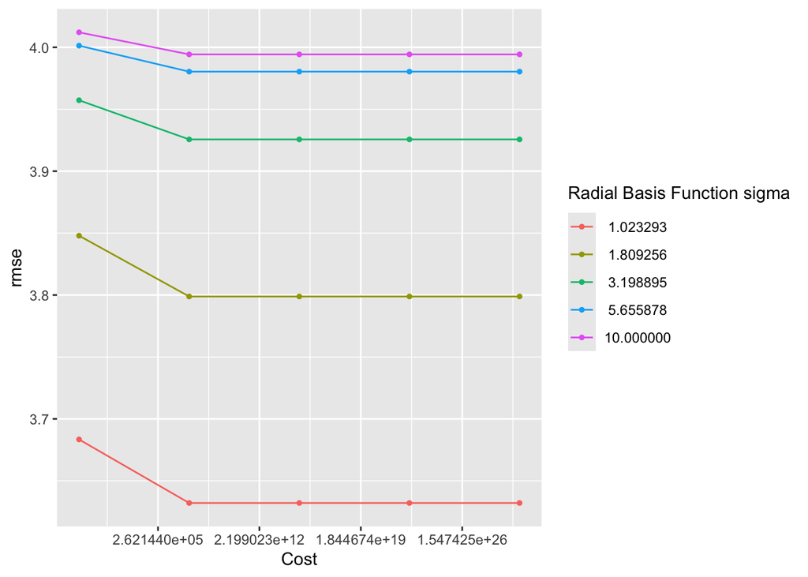

```r
# Workflow for SVM
svm_workflow <- workflow() %>%
  add_recipe(player_recipe) %>%
  add_model(svm_model)

# Hyperparameter tuning
svm_grid <- grid_regular(
  cost(range = c(0.1, 100)),
  rbf_sigma(range = c(0.01, 1)),
  levels = 5
)

svm_results <- tune_grid(
  svm_workflow,
  resamples = folds,
  grid = svm_grid,
  metrics = metric
)

autoplot(svm_results)
```

```r
svm_metrics <- svm_results %>%
  collect_metrics() %>%
  filter(.metric == "rmse") %>%
  mutate(mse = mean^2)

print(svm_metrics)
```

```
## # A tibble: 25 × 9
##       cost rbf_sigma .metric .estimator  mean     n std_err .config          mse
##      <dbl>     <dbl> <chr>   <chr>      <dbl> <int>   <dbl> <chr>          <dbl>
##  1 1.07e 0      1.02 rmse    standard    3.68     5   0.258 Preprocessor1…  13.6
##  2 3.53e 7      1.02 rmse    standard    3.63     5   0.237 Preprocessor1…  13.2
##  3 1.17e15      1.02 rmse    standard    3.63     5   0.237 Preprocessor1…  13.2
##  4 3.84e22      1.02 rmse    standard    3.63     5   0.237 Preprocessor1…  13.2
##  5 1.27e30      1.02 rmse    standard    3.63     5   0.237 Preprocessor1…  13.2
##  6 1.07e 0      1.81 rmse    standard    3.85     5   0.259 Preprocessor1…  14.8
##  7 3.53e 7      1.81 rmse    standard    3.80     5   0.241 Preprocessor1…  14.4
##  8 1.17e15      1.81 rmse    standard    3.80     5   0.241 Preprocessor1…  14.4
##  9 3.84e22      1.81 rmse    standard    3.80     5   0.241 Preprocessor1…  14.4
## 10 1.27e30      1.81 rmse    standard    3.80     5   0.241 Preprocessor1…  14.4
## # ℹ 15 more rows
```

```r
best_svm <- svm_metrics %>%
  arrange(mse) %>%
  head(1)

best_svm
```

```
## # A tibble: 1 × 9
##        cost rbf_sigma .metric .estimator  mean     n std_err .config         mse
##       <dbl>     <dbl> <chr>   <chr>      <dbl> <int>   <dbl> <chr>         <dbl>
## 1 35344931.      1.02 rmse    standard    3.63     5   0.237 Preprocessor…  13.2
```

# Model Results

```r
best_elastic_net_mse <- best_elastic_net %>%
  pull(mse)

best_rf_mse <- best_rf %>%
  pull(mse)

best_gbt_mse <- best_gbt %>%
  pull(mse)

best_svm_mse <- best_svm %>%
  pull(mse)

mse_table <- tibble::tibble(Model = c("Elastic net", "Random forest", "Gradient boosted tree", "Support Vector Machine"),
  `MSE Values` = c(best_elastic_net_mse, best_rf_mse, best_gbt_mse, best_svm_mse))

print(mse_table)
```

```
## # A tibble: 4 × 2
##   Model                  `MSE Values`
##   <chr>                         <dbl>
## 1 Elastic net                   10.1
## 2 Random forest                  9.61
## 3 Gradient boosted tree          9.60
## 4 Support Vector Machine        13.2
```

# Fitting the best model to the testing set

Althought the updated random forest model had the lowest MSE, it was by a margin, and considering that the other models performed worse with the lane variable dropped, we will proceed with the original random forest model to fit to the testing set.

```r
best_model_params <- rf_results %>%
  select_best()

best_model_workflow <- rf_workflow %>%
  finalize_workflow(best_model_params)

final_fit <- best_model_workflow %>%
  fit(data = player_test)

rf_predictions <- predict(final_fit, new_data = player_test) %>%
  bind_cols(player_test)
```

# Testing error of the best model

```r
rf_testing_error <- rf_predictions %>%
  metrics(truth = kda, estimate = .pred)

rf_testing_error
```

```
## # A tibble: 3 × 3
##   .metric .estimator .estimate
##   <chr>   <chr>          <dbl>
## 1 rmse    standard       1.48
## 2 rsq     standard       0.968
## 3 mae     standard       0.869
```

# Conclusion

Despite these findings, efforts to improve model performance through variable selection and tuning resulted in only marginal gains. This suggests that further experimentation with feature engineering, such as creating new variables to capture nuanced gameplay dynamics or interactions, may be necessary to unlock more significant improvements.Additionally, the quality of the dataset may have constrained the models’ predictive power. Moving forward, implementing more robust data collection methods—such as integrating larger, more diverse samples could provide richer information for analysis. Enhanced data preprocessing techniques, such as addressing potential biases or capturing additional game-specific metrics, might also yield better results. By refining both feature engineering and data collection processes, future models could not only achieve higher accuracy but also provide deeper insights into the factors driving player performance.